| title: “Operation” |
| --- |
| author: “PB21151825 俞越” |
| date: “2023-05-12” |
| output: html_document |

# 红楼梦作者之谜

### ——应用统计学方法探究红楼梦1-80回与81-120回的差别

#### 俞越 PB21151825

## 1 背景

### 1.1 关于红楼梦作者之谜

红楼梦是中国四大名著之一， 曹雪芹自述“批阅十载，增删五次”， 方成此书；而红楼梦整个故事的发展， 也正是曹雪芹家族的镜像。  
红楼梦全书共120回， 前80回比较公认的作者是曹雪芹，后40回原作散失， 不知作者。  
胡适先生“大胆假设”， 认为后四十回为高鹗续书；白先勇则认为， 后四十回前后呼应， 一百二十回应全系曹雪芹所做。  
大家各执一词， 学术界仍无定论。

### 1.2 探究谜题的整体思路

假若前80回与后40回的作者非同一人，则两部分的内容将体现不同的语言风格与习惯。曹雪芹出生于富足官宦之家，随后遭遇家道中落，最终凄惨落魄、一贫如洗。他的出身易于使他的文笔优美、富有文学气息，同时对贵族的生活刻画真实详尽；他的人生经历又让他的情感表达倾向于细腻。鉴于这些特点，我将**诗歌**与**表意美好的字**作为探究的要点之二。同时，也结合常识上考察不同写作风格的要点，如**段落长度**、**虚词使用**等等。  
我将1-40回与41-80回内容的对比视为**对照组**，41-80回与81-120回内容的对比视为**实验组**，这显然是合理的。  
具体分析观察举例：选定某一指标（如词频TF）后，41-80回中每回该指标的数值构成向量X，81-120回类似地构成向量Y，以X与Y为两独立变量作t检验，计算出p值，p值越小，则可认为两变量相关程度越低，并特别关注p值小于0.001的情形。

## 2 分析红楼梦

### 2.1 初步工作

清理工作空间

```r
cat("\014");
```

```r
rm(list = ls())
```

引入自编写的函数

```r
source('Functions.R')
```

引入需要的R包

```r
library(stringr)
```

读入红楼梦文本，初步按1-40、41-80、81-120分**类**

```r
MyText = readLines('红楼梦.txt')
MyText = DivideTextBySession(MyText)
```

细分文本，得到每个类中按**回**分的列表MyChaptersX与每个类中仅去除了回名所在行的向量MyTextX

```r
MyText1     = MyText[[1]]
MyChapters1 = DivideTextByChapter(MyText1)
MyText1     = CleanText(MyText1)

MyText2     = MyText[[2]]
MyChapters2 = DivideTextByChapter(MyText2)
MyText2     = CleanText(MyText2)

MyText3     = MyText[[3]]
MyChapters3 = DivideTextByChapter(MyText3)
MyText3     = CleanText(MyText3)
#分出1-40，41-80，81-120回的文本内容并生成各元素为每回正文的列表MyChaptersX与只清除了回名所在行的全部内容MyTextX
#完成初步文本清洗工作
```

### 2.2 段落平均长度

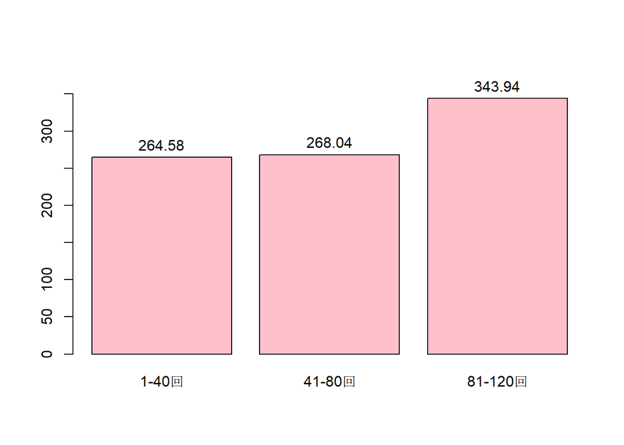

```r
#计算得各类中的段落平均长度
para_len1 = round(mean(nchar(MyText1)), 2)
para_len2 = round(mean(nchar(MyText2)), 2)
para_len3 = round(mean(nchar(MyText3)), 2)

#输出三个类中的段落平均长度的直方图
DisplayDataGraph_Single(c(para_len1, para_len2, para_len3))
```

```r
#执行t检验
pValues = Operate_tTest(MyChapters1, MyChapters2, MyChapters3, GetParaLengthVector)[[1]]
#输出对照组何实验组的p值表
Display_pValueTable(pValues)
```

```
##    对照组   实验组
##  0.662645 0.001661
```

从直方图上看，对照组差距不明显，而实验组差距较大；  
从p值表上看，实验组的p值已接近0.001。  
可见，在段落平均长度方面，实验组体现了不同的写作风格

### 2.3 诗歌数量

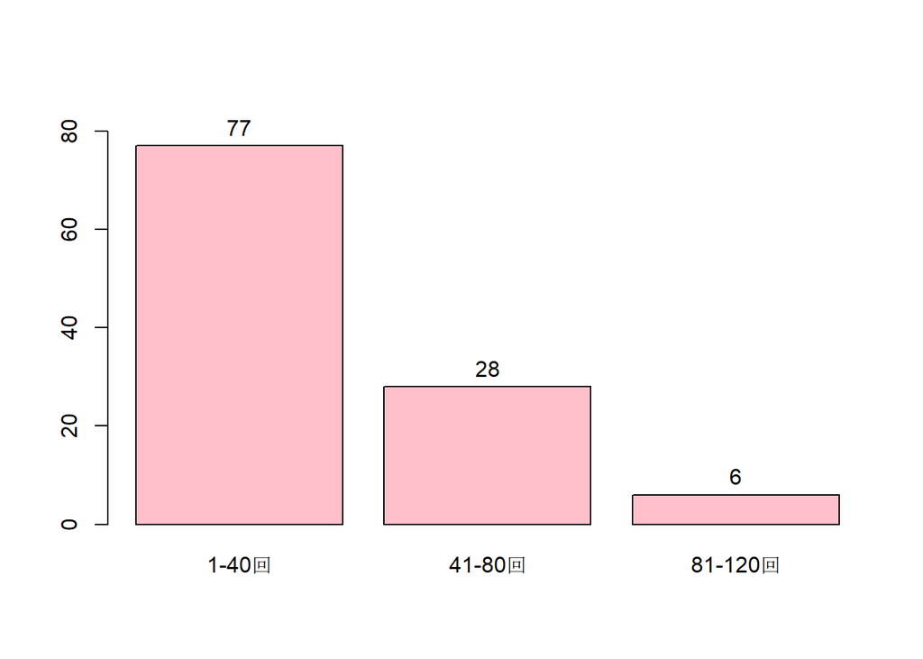

```r
#计算得每个类中诗歌的数量，下面操作类似上一小节
poem_count1 = GetPoemCount(MyText1)
poem_count2 = GetPoemCount(MyText2)
poem_count3 = GetPoemCount(MyText3)

DisplayDataGraph_Single(c(poem_count1, poem_count2, poem_count3))
```

```r
pValues = Operate_tTest(MyChapters1, MyChapters2, MyChapters3, GetPoemCountVector)[[1]]
Display_pValueTable(pValues)
```

```
##    对照组   实验组
##  0.058224 0.023369
```

曹雪芹的文学素养必不在可能的续作者（高鹗或无名氏）之下（大胆猜测，应该高出许多），他在海棠诗社等情节中充分展现了他的赋诗才华，因此我猜测，前80回中诗歌的数量将尤为突出。由直方图可以看出，事实正是如此。

### 2.4 对话内容占比

```r
dialogue_ratio1 = CalculateDialogueRatio(MyText1)
dialogue_ratio2 = CalculateDialogueRatio(MyText2)
dialogue_ratio3 = CalculateDialogueRatio(MyText3)

cat(sep = '',
    '各部分对话占比对比：\n',
    '1 - 40:\t', dialogue_ratio1, '\n', '41- 80:\t', dialogue_ratio2, '\n', '81-120:\t', dialogue_ratio3)
```

```
## 各部分对话占比对比：
## 1 - 40:  45.18%
## 41- 80:  51.25%
## 81-120:  50.64%
```

单看对话内容占比这一方面，实验组差距不明显，对探究难有帮助

### 2.5 文言虚词

```r
XuCiVector  = c('者', '则', '何', '也', '矣', '之', '其', '亦', '乃', '哉')
#选定十个最常见的文言虚词
XuCiVector1 = c('者', '则', '矣', '其', '亦', '乃', '哉')
XuCiVector2 = c('何', '也', '之')
#由于“何”“也”“之”的词频远大于其它七个虚词，故为作图方便，将它们分别分析
```

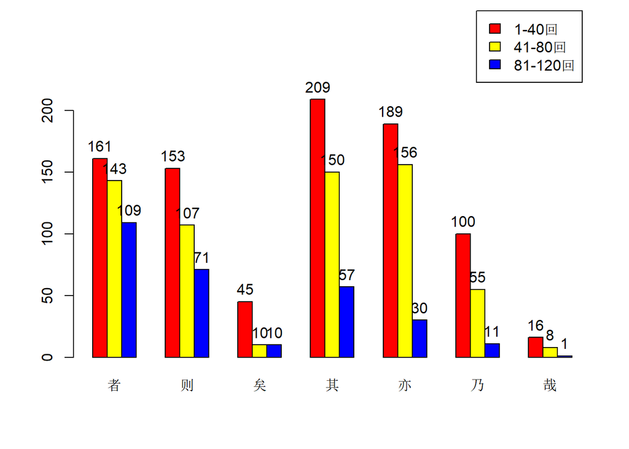

```r
XuCipValues1 = c()
XuCiCounts1  = c()
for (XuCi in XuCiVector1)
{
  XuCiInfo1    = Operate_tTest(MyChapters1, MyChapters2, MyChapters3, GetTFVector, XuCi)
  XuCipValues1 = append(XuCipValues1, XuCiInfo1[[1]])
  XuCiCounts1  = append(XuCiCounts1,  XuCiInfo1[[2]])
}
#XuCipValues1, XuCiCounts1分别有2 * 7组、3 * 7组元素，对应['者', '则', '矣', '其', '亦', '乃', '哉']7个虚词
#下面的XuCipValues2, XuCiCounts2类似

DisplayDataGraph_Multiple(XuCiCounts1, var_names = XuCiVector1, type = 'barplot')
```

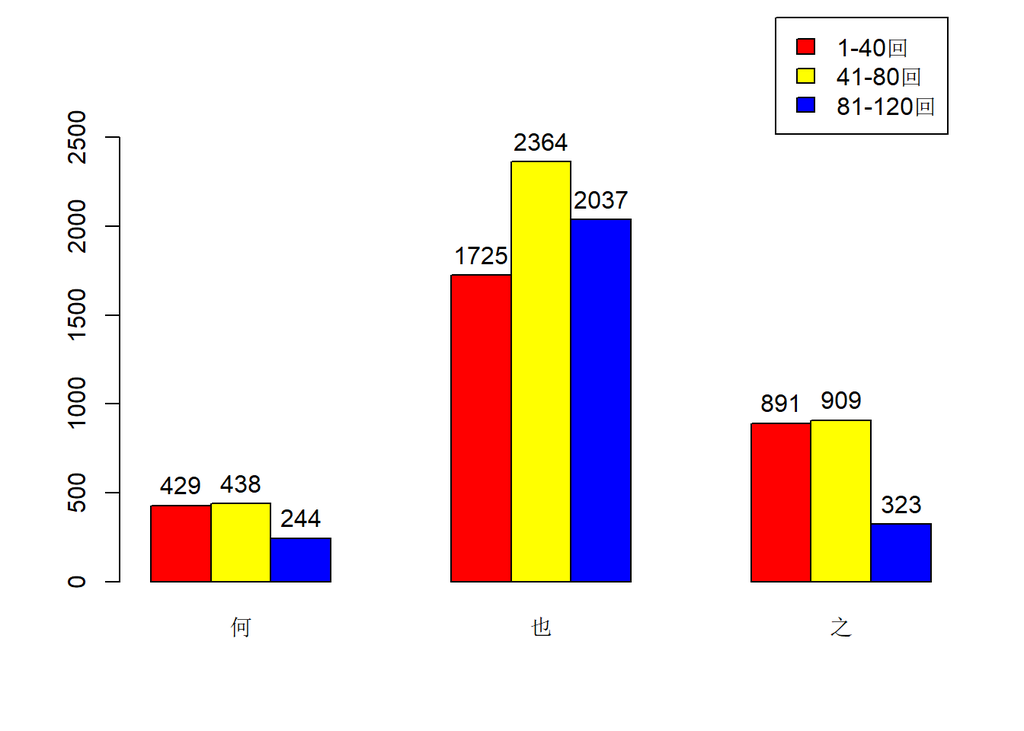

```r
XuCipValues2 = c()
XuCiCounts2  = c()
for (XuCi in XuCiVector2)
{
  XuCiInfo2    = Operate_tTest(MyChapters1, MyChapters2, MyChapters3, GetTFVector, XuCi)
  XuCipValues2 = append(XuCipValues2, XuCiInfo2[[1]])
  XuCiCounts2  = append(XuCiCounts2,  XuCiInfo2[[2]])
}

DisplayDataGraph_Multiple(XuCiCounts2, var_names = XuCiVector2, type = 'barplot')
```

```r
Display_pValueTable(c(XuCipValues1, XuCipValues2), var_names = c(XuCiVector1, XuCiVector2))
```

```
##      对照组   实验组
## 者 0.647372 0.252492
## 则 0.135698 0.108649
## 矣 0.011280 1.000000
## 其 0.296661 0.008731
## 亦 0.433608 0.000066
## 乃 0.097223 0.004515
## 哉 0.238314 0.046120
## 何 0.883814 0.000218
## 也 0.000133 0.023609
## 之 0.920087 0.000005
```

从直方图上看，各虚词在前80回的词频基本上大于后40回，让前80回显得更为“文绉绉”，这与作者曹雪芹的特点匹配。  
从p值表上看，“亦”“何”“之”在实验组的p值极低，反映出实验组中这三个虚词的词频差距很大。

### 2.6 称呼名词

```r
NounVector1 = c('丫鬟', '婶子', '婶娘')
```

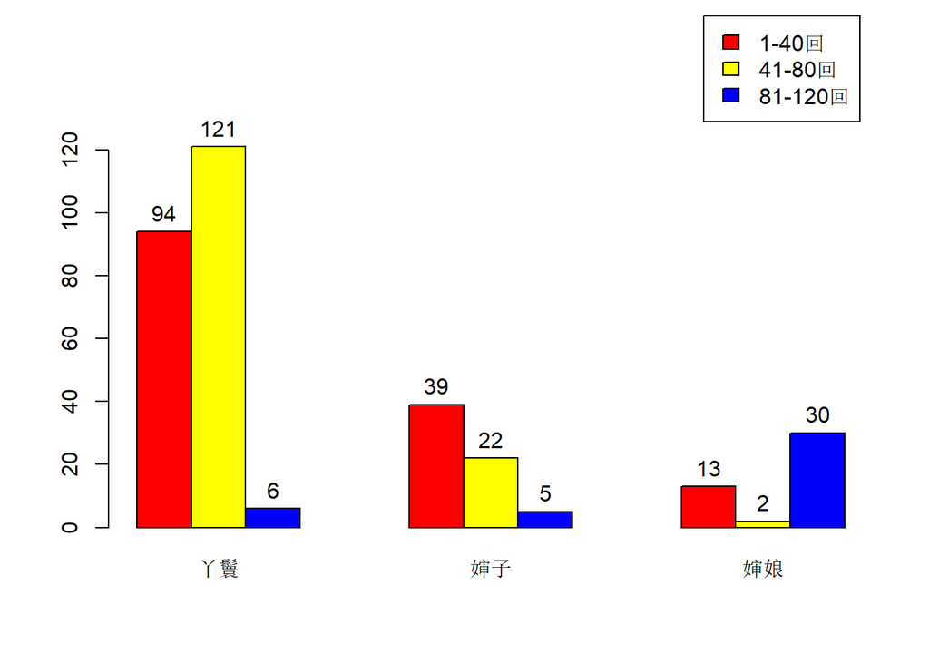

```r
NounpValues1 = c()
NounCounts1  = c()
for (Noun in NounVector1)
{
  NounInfo1    = Operate_tTest(MyChapters1, MyChapters2, MyChapters3, GetTFVector, Noun)
  NounpValues1 = append(NounpValues1, NounInfo1[[1]])
  NounCounts1  = append(NounCounts1,  NounInfo1[[2]])
}

DisplayDataGraph_Multiple(NounCounts1, var_names = NounVector1)
```

```r
Display_pValueTable(NounpValues1, var_names = NounVector1)
```

```
##        对照组   实验组
## 丫鬟 0.287996 0.000000
## 婶子 0.343265 0.067401
## 婶娘 0.290106 0.043273
```

```r
NounVector2 = c('嬷嬷', '乳母', '奶母', '奶娘')
```

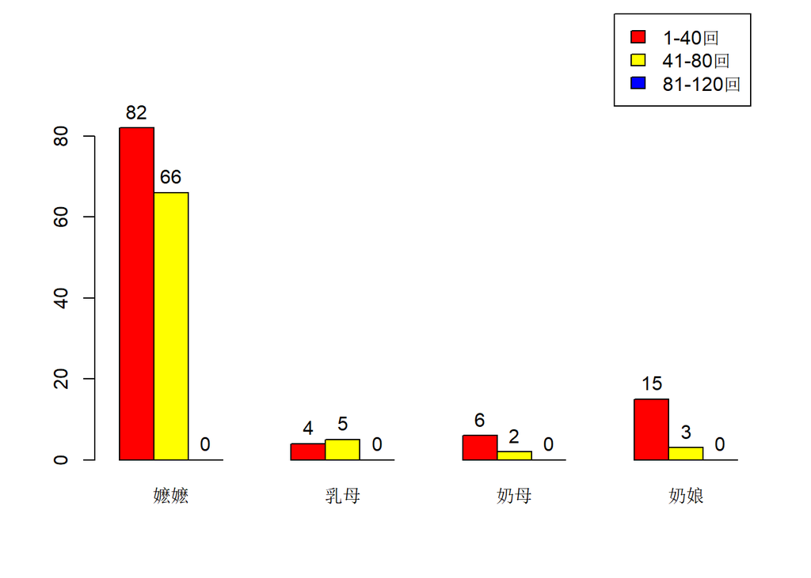

```r
NounCounts2  = c()
for (Noun in NounVector2)
{
  NounInfo2   = Operate_tTest(MyChapters1, MyChapters2, MyChapters3, GetTFVector, Noun)
  NounCounts2 = append(NounCounts2, NounInfo2[[2]])
}

DisplayDataGraph_Multiple(NounCounts2, var_names = NounVector2)
```

红楼梦中表达“奶妈”意思的词有很多，图表中的四个仅是部分。易见在后四十回中，这四个词甚至从未出现。  
虽然显示出来的差别极大，但这作为证据仍不够有力。我的解释是，后四十回中剧情多涉及爱恨乃至家族、军政、君臣等偏宏大的主题内容，留给日常琐屑（前80回主要内容之一）的笔墨不多，奶妈这类角色自然难以有出场机会。

### 2.7 表意美好的字

```r
KeyWordVector  = c('眉', '肤', '俊', '美', '秀', '清', '润', '洁', '花', '茶')
#note:“玉”“凤”“春”因人名而不再考虑，“水”因为与日常生活重合较大不再考虑
KeyWordVector1 = c('眉', '肤', '俊', '美', '秀', '润', '洁')
KeyWordVector2 = c('花', '清', '茶')
```

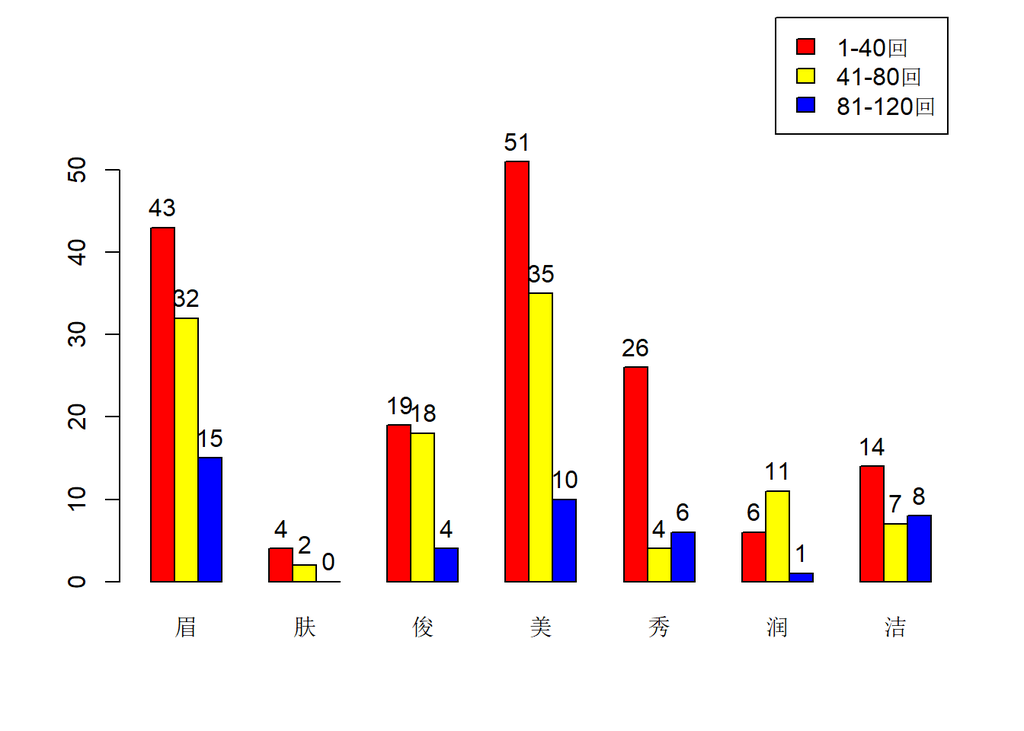

```r
KeyWordpValues1 = c()
KeyWordCounts1  = c()
for (KeyWord in KeyWordVector1)
{
  KeyWordInfo1    = Operate_tTest(MyChapters1, MyChapters2, MyChapters3, GetTFVector, KeyWord)
  KeyWordpValues1 = append(KeyWordpValues1, KeyWordInfo1[[1]])
  KeyWordCounts1  = append(KeyWordCounts1,  KeyWordInfo1[[2]])
}

DisplayDataGraph_Multiple(KeyWordCounts1, var_names = KeyWordVector1)
```

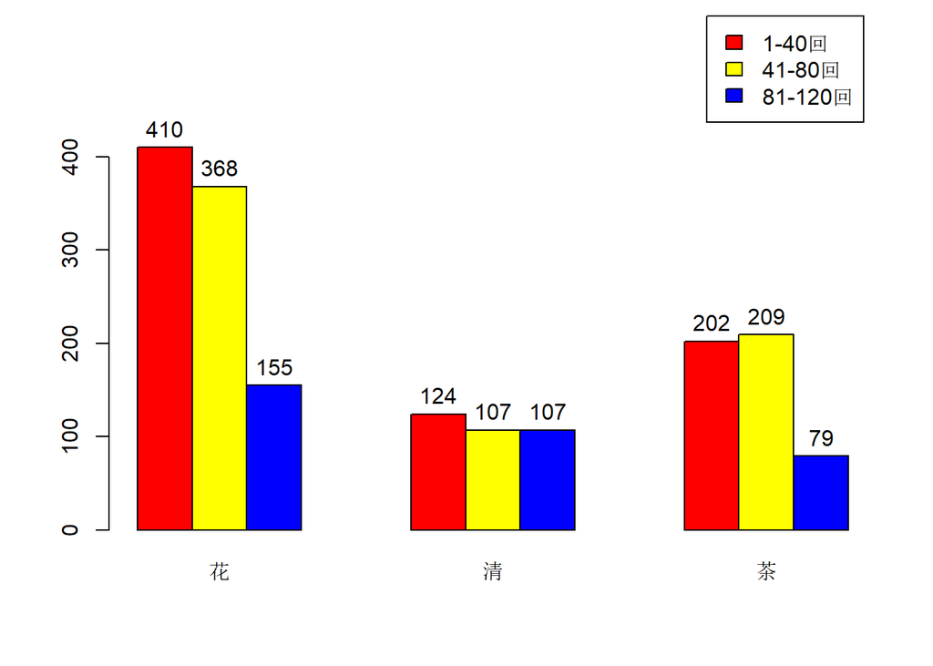

```r
KeyWordpValues2 = c()
KeyWordCounts2  = c()
for (KeyWord in KeyWordVector2)
{
  KeyWordInfo2    = Operate_tTest(MyChapters1, MyChapters2, MyChapters3, GetTFVector, KeyWord)
  KeyWordpValues2 = append(KeyWordpValues2, KeyWordInfo2[[1]])
  KeyWordCounts2  = append(KeyWordCounts2,  KeyWordInfo2[[2]])
}

DisplayDataGraph_Multiple(KeyWordCounts2, var_names = KeyWordVector2)
```

```r
Display_pValueTable(c(KeyWordpValues1, KeyWordpValues2), var_names = c(KeyWordVector1, KeyWordVector2))
```

```
##      对照组   实验组
## 眉 0.339356 0.008201
## 肤 0.473521 0.159911
## 俊 0.869504 0.008478
## 美 0.442018 0.011322
## 秀 0.004357 0.581081
## 润 0.236374 0.008670
## 洁 0.259664 0.806703
## 花 0.608029 0.000196
## 清 0.492747 1.000000
## 茶 0.867873 0.000235
```

总体来看，在前80回中，这些表意美好的字出现频率高于后40回，这可认为与背景中提到的“曹雪芹文笔优美”匹配。  
特别注意，“茶”一词跟“贵族生活”具有一定的相关性（品茶往往与风雅相联系，受达官贵人追捧）。可能的续作者几乎不可能有曹雪芹一样显赫的出身，故猜测他较不善于描写贵族生活是合理的。因此，“茶”字的频率变化在某种程度上可以佐证后40回的作者并非曹雪芹。

### 2.8 对2.7过程的改进

在观察2.7所得结果时，我发现，1-40回与41-80回中频率数值有波动，这有可能减弱对比效果（尤其是与81-120回的对比）。  
既然1-40回与41-80回同出曹雪芹之手，为何不对它们的频率数值取均值后合为一个整体，并参与随后的t检验呢？

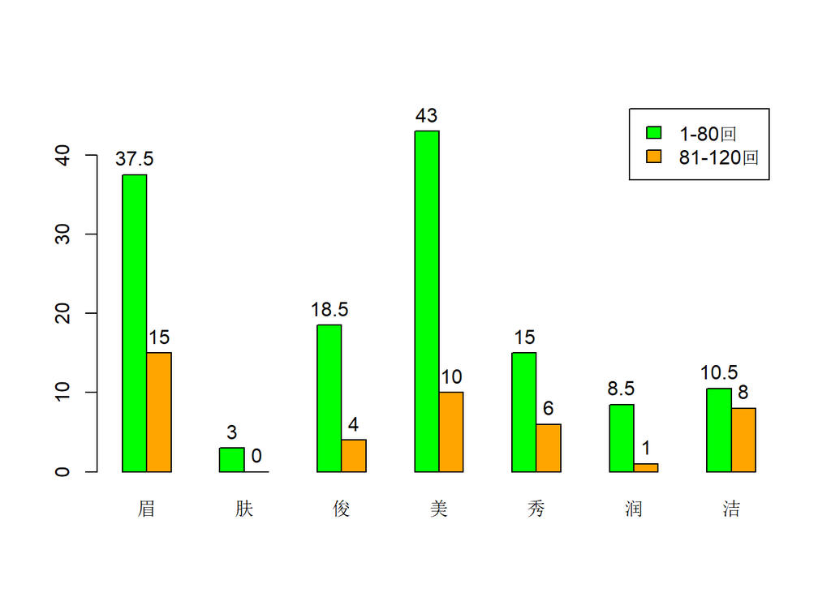

```r
KeyWordpValues1 = c()
KeyWordCounts1  = c()
for (KeyWord in KeyWordVector1)
{
  KeyWordInfo1    = Operate_tTest_Improved(MyChapters1, MyChapters2, MyChapters3, GetTFVector, KeyWord)
  KeyWordpValues1 = append(KeyWordpValues1, KeyWordInfo1[[1]])
  KeyWordCounts1  = append(KeyWordCounts1,  KeyWordInfo1[[2]])
}

DisplayDataGraph_Improved(KeyWordCounts1, var_names = KeyWordVector1)
```

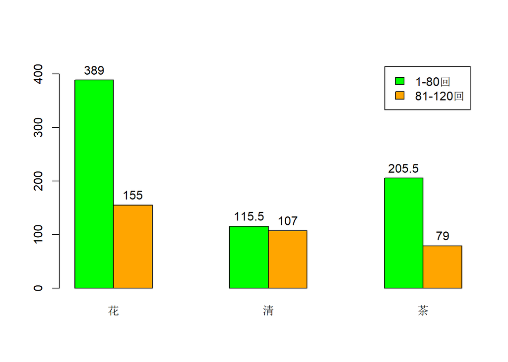

```r
KeyWordpValues2 = c()
KeyWordCounts2  = c()
for (KeyWord in KeyWordVector2)
{
  KeyWordInfo2    = Operate_tTest_Improved(MyChapters1, MyChapters2, MyChapters3, GetTFVector, KeyWord)
  KeyWordpValues2 = append(KeyWordpValues2, KeyWordInfo2[[1]])
  KeyWordCounts2  = append(KeyWordCounts2,  KeyWordInfo2[[2]])
}

DisplayDataGraph_Improved(KeyWordCounts2, var_names = KeyWordVector2)
```

```r
Display_pValueTable_Improved(c(KeyWordpValues1, KeyWordpValues2), var_names = c(KeyWordVector1, KeyWordVector2))
```

```
##         p值
## 眉 0.002311
## 肤 0.032050
## 俊 0.000030
## 美 0.001963
## 秀 0.047739
## 润 0.002404
## 洁 0.571744
## 花 0.000007
## 清 0.629061
## 茶 0.000003
```

对比改进前后的p值，改进后的p值确实更突出了前80回与后40回的差距。  
但是，这样的改进合理性有待商榷，因为它删去了对照组。

## 3 分析三国演义

不同于红楼梦，三国演义全文为同一作者罗贯中所著，对三国演义作同于以上红楼梦的分析，结果将有助于此次探究。  
由于时间关系，对三国演义的分析只选取一个方面：文言虚词。  
在三国演义的分析中，对照组、实验组的定义同红楼梦（三国演义也恰有120回）。

### 3.1 初步工作

读入三国演义文本，初步按1-40、41-80、81-120分**类**

```r
MyText = readLines('三国演义.txt')
MyText = DivideTextBySession(MyText)
```

细分文本，得到每个类中按**回**分的列表MyChaptersX与每个类中仅去除了回名所在行的向量MyTextX

```r
MyChapters1 = DivideTextByChapter(MyText[[1]])
MyChapters2 = DivideTextByChapter(MyText[[2]])
MyChapters3 = DivideTextByChapter(MyText[[3]])
#分出1-40，41-80，81-120回的文本内容并生成各元素为每回正文的列表MyChaptersX与只清除了回名所在行的全部内容MyTextX
#完成初步文本清洗工作
```

### 3.2 文言虚词

```r
XuCiVector  = c('者', '则', '何', '也', '矣', '之', '其', '亦', '乃', '哉')
#选定十个最常见的文言虚词
XuCiVector1 = c('者', '则', '矣', '其', '亦', '乃', '哉')
XuCiVector2 = c('何', '之', '也')
#由于“何”“也”“之”的词频远大于其它七个虚词，故为作图方便，将它们分开进行分析
```

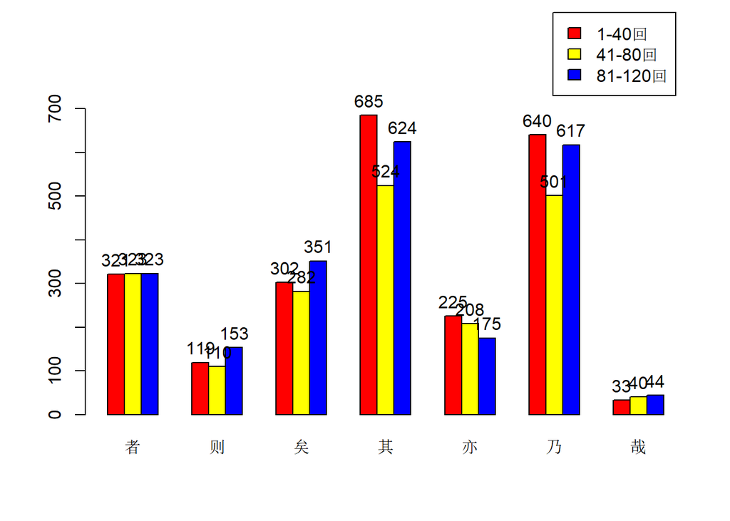

```r
XuCipValues1 = c()
XuCiCounts1  = c()
for (XuCi in XuCiVector1)
{
  XuCiInfo1    = Operate_tTest(MyChapters1, MyChapters2, MyChapters3, GetTFVector, XuCi)
  XuCipValues1 = append(XuCipValues1, XuCiInfo1[[1]])
  XuCiCounts1  = append(XuCiCounts1,  XuCiInfo1[[2]])
}
#XuCipValues1, XuCiCounts1分别有2 * 7组、3 * 7组元素，对应['者', '则', '矣', '其', '亦', '乃', '哉']7个虚词
#下面的XuCipValues2, XuCiCounts2类似

DisplayDataGraph_Multiple(XuCiCounts1, var_names = XuCiVector1, type = 'barplot')
```

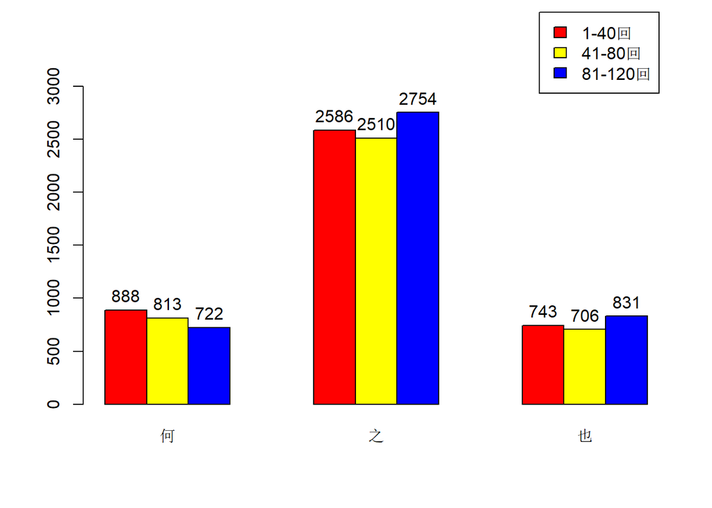

```r
XuCipValues2 = c()
XuCiCounts2  = c()
for (XuCi in XuCiVector2)
{
  XuCiInfo2    = Operate_tTest(MyChapters1, MyChapters2, MyChapters3, GetTFVector, XuCi)
  XuCipValues2 = append(XuCipValues2, XuCiInfo2[[1]])
  XuCiCounts2  = append(XuCiCounts2,  XuCiInfo2[[2]])
}

DisplayDataGraph_Multiple(XuCiCounts2, var_names = XuCiVector2, type = 'barplot')
```

```r
Display_pValueTable(c(XuCipValues1, XuCipValues2), var_names = c(XuCiVector1, XuCiVector2))
```

```
##      对照组   实验组
## 者 0.955132 1.000000
## 则 0.732519 0.063816
## 矣 0.529165 0.042099
## 其 0.003986 0.066228
## 亦 0.512789 0.204933
## 乃 0.010038 0.009824
## 哉 0.495287 0.693362
## 何 0.273060 0.125191
## 之 0.673191 0.137697
## 也 0.507224 0.019456
```

## 4 总结与反思

### 4.1 对分析的总结

在对红楼梦的分析中，我采用了内部对照的方法，分析了“段落长度”“诗歌数量”“文言虚词”等6个要点，在除“对话占比”外的五个要点中，我均通过所得数据找到了前80回与后40回语言风格不同的支持，从而增强了推断“前80回与后40回两部分是由两个不同作者所著”这一猜测的可能性。  
在对三国演义的分析中，我采用了外部对照的方法，分析了“文言虚词”1个要点，所得结果以小见大，可推测在同一作者所著的文学作品中，不同部分的语言风格差异不大，而是相对稳定。  
综合对两部名著的分析，我给出的结论是：**红楼梦前80回与后40回并非同一作者所写，即后40回并非曹雪芹所著**。